# Voter Turnout vs DMV Hours/Distances

# PART 1: DMV DATA CLEANING

```python
import pandas as pd
import numpy as np
import matplotlib.pyplot as plt
import seaborn as sns
import geopandas as gdp
from geopy import Nominatim
from geopy import GoogleV3
from geopy.exc import GeopyError
from geopy import distance
import warnings
import statsmodels.api as sm
from statsmodels.iolib.summary2 import summary_col
import re

warnings.filterwarnings('ignore')
```

## Getting DMV hours and locations

Data copied from:  
https://www.safemotorist.com/Alabama/DMV_Locations.aspx  
into Google Sheets, then exported to CSV file.

```python
dmv = pd.read_csv('alabama_dmv.csv')
dmv.head()
```

[output not shown]

## Extracting relevant information using regular expressions

For sake of brevity I put all this code in one cell. However, each extract was first tested with str.match(regular_expression) to make sure there was indeed a match for each row.

```python
dmv.rename(columns={'city and zip\n':'city and zip'}, inplace = True)
dmv['days_open'] = dmv['hours'].str.extract(r'([MTWF\.]{4,5})')
dmv['days_open'] = dmv['days_open'].str.replace('\.','')
dmv['opens'] = dmv['hours'].str.extract('(\d:\d\d) AM')
dmv['closes'] = dmv['hours'].str.extract(r'(\d:\d\d)\s*PM')

# ml standing for multi-level. Two regex matches are found and creates messy multilevel dataframe
ml = dmv['lunch'].str.extractall(r'(\d{1,2}:\d{1,2})').reset_index()
dmv['lunch_starts'] = ml[ml['match']==0].set_index('level_0')[0]
dmv['lunch_ends'] = ml[ml['match']==1].set_index('level_0')[0]

# Extracting city, one value does not fit the regex string so it is assigned manually
dmv['city'] = dmv['city and zip'].str.extract(r'([\w\s]*)\n')
missing_val = dmv[~dmv['city and zip'].str.match(r'([\w\s]*)\n')]['city and zip'][26]
dmv['city'][26] = missing_val

# Extracting zipcode, two values do not fit the regex string so they're assigned manually
dmv['zip'] = dmv['city and zip'].str.extract(r'(\d{5})')
dmv['zip'][26] = '36027'
dmv['zip'][66] = '35136'
```

## Getting the hours open in a day

Note that the minutes are converted to hours as well (by dividing by 60) so that, for example, 1.5 hours is of course 1 hours 30 minutes.

```python
def time_open(row):

    total_time = 0.0

    # All DMV's in this dataset open before 12 so subtracting from 12 gives hours open before 12.
    # h_open standing for "hour open" and m_open for "minute_open".
    h_open,m_open = re.split(r':', row['opens'])
    total_time += 12 - (float(h_open)+float(m_open)/60)

    # All DMV's in this dataset close after 12 so we add to the total time simply the hour and its minutes
    h_close,m_close = re.split(r':', row['closes'])
    total_time += float(h_close) + float(m_close)/60

    # Checking if the DMV closes for lunch
    if row['lunch_starts'] is not np.nan:
        lunch_time = 0.0

        lh_start,lm_start = re.split(r':', row['lunch_starts'])
        lunch_time += 12 - (float(lh_start)+float(lm_start)/60)

        # Here we must mod 12 as some DMV lunches end at, for example, 12:30
        lh_ends,lm_ends = re.split(r':', row['lunch_ends'])
        lunch_time += float(lh_ends)%12 + float(lm_ends)/60

        total_time -= lunch_time

    return total_time


daily_hours = dmv.apply(lambda row: time_open(row), axis=1)
dmv['daily_hours'] = daily_hours
daily_hours.value_counts()
```

```
8.000000    22
6.000000    19
8.500000    12
7.500000    10
7.000000     9
9.000000     4
5.500000     2
7.333333     1
6.250000     1
dtype: int64
```

## Getting the total number of days open per week

```python
def get_num_days_open(row):
    return len(row['days_open'])

num_days_open = dmv.apply(lambda row: get_num_days_open(row), axis=1)
dmv['num_days_open'] = num_days_open
num_days_open.value_counts()
```

```
5    34
1    29
2    14
4     3
dtype: int64
```

## Getting the total number of hours open per week

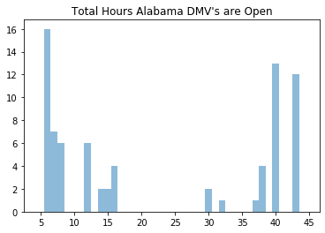

```python
def total_time_open(row):
    return row['daily_hours'] * row['num_days_open']

total_hours = dmv.apply(lambda row: total_time_open(row), axis = 1)
dmv['total_hours'] = total_hours

plt.hist(total_hours, bins=np.arange(4.5, 45, 1), alpha=0.5);
plt.title('Total Hours Alabama DMV\'s are Open');
```

# PART 2: VOTER TURNOUT DATA CLEANING

## Reading in presidential election data

Voting data sourced from: https://github.com/tonmcg/US_County_Level_Election_Results_08-16

```python
file = '2016_County_Lev_Pres_Results.csv'
pres = pd.read_csv(file)

# Only need Alabama data
pres = pres[pres['state_abbr']=='AL']

# Renaming some columns
pres.rename(columns = {'county_name':'county','state_abbr':'state'}, inplace = True)
pres = pres[['total_votes','votes_dem','votes_gop','county']]

pres.head()
```

|  | total_votes | votes_dem | votes_gop | county |
| --- | --- | --- | --- | --- |
| 29 | 24661.0 | 5908.0 | 18110.0 | Autauga County |
| 30 | 94090.0 | 18409.0 | 72780.0 | Baldwin County |
| 31 | 10390.0 | 4848.0 | 5431.0 | Barbour County |
| 32 | 8748.0 | 1874.0 | 6733.0 | Bibb County |
| 33 | 25384.0 | 2150.0 | 22808.0 | Blount County |

## Reading in census population data

Population data sourced from: https://factfinder.census.gov/faces/tableservices/jsf/pages/productview.xhtml?src=bkmk

```python
# Note: changed .csv to .txt and manually set encoding as 'utf-8' to get past encoding read-in errors
file = 'PEP_2018_PEPANNRES2.txt'
pop = pd.read_csv(file,encoding = 'utf-8')

# Getting rid of trash columns
new_cols = {'GEO.display-label':'place', 'rescen42010':'pop'}
pop = pop[['GEO.display-label','rescen42010']].rename(columns=new_cols)

# Extracting county name and state
pop = pop.merge(pop['place'].str.extract(r'(.*),\s(.*)'), left_index=True, right_index=True).drop(columns='place')
pop.rename(columns = {0:'county',1:'state'}, inplace = True)

# Cleaning for just Indiana
pop = pop[pop['state'] == 'Alabama']

pop.head()
```

|  | pop | county | state |
| --- | --- | --- | --- |
| 0 | 54571 | Autauga County | Alabama |
| 1 | 182265 | Baldwin County | Alabama |
| 2 | 27457 | Barbour County | Alabama |
| 3 | 22915 | Bibb County | Alabama |
| 4 | 57322 | Blount County | Alabama |

## Merging presidential election data with census data

```python
merged = pop.set_index('county').join(pres.set_index('county'), how='inner', lsuffix='l').reset_index()

merged.head()
```

[output not shown]

## Getting voter turnout column

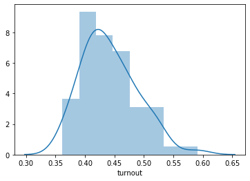

```python
def get_turnout(row):
    return row['total_votes'] / row['pop']

merged['turnout'] = merged.apply(lambda row: get_turnout(row), axis=1)

sns.distplot(merged['turnout']);
```

## Getting the full address using GeoPy

The full address includes the county name of each city, with this extracted we can merge with the voter turnout data.

```python
locator = Nominatim(user_agent="myGeocoder")

def get_full_address(row):
    place = row['city'] + ", Alabama, " + str(row['zip'])
    location = locator.geocode(place)
    return location.address

full_address = dmv.apply(lambda row: get_full_address(row), axis = 1)
dmv['full_address'] = full_address
full_address.head()
```

```
0    Abbeville, Henry County, Alabama, 36310, Unite...
1    Andalusia, Covington County, Alabama, United S...
2    Ashland, Clay County, Alabama, United States o...
3    Ashville, St. Clair County, Alabama, 35953, Un...
4    Athens, Limestone County, Alabama, 35611, Unit...
dtype: object
```

## Getting county from full address using regular expression

```python
def get_county(row):
    return re.findall(r'\s?([\w\s]* County),', row['full_address'])[0]

dmv['county'] = dmv.apply(lambda row: get_county(row), axis=1)

# In voter data Clair County written as St. Clair County, switching it here to aid merging!
dic = {'Clair County': 'St. Clair County'}
dmv.replace({'county':dic}, inplace=True)

dmv['county'].head()
```

```
0        Henry County
1    Covington County
2         Clay County
3    St. Clair County
4    Limestone County
Name: county, dtype: object
```

## Merging DMV data and voter turnout data

Note that it appears one county is missing a DMV as

```
len(merged['county'].unique())
```

returns 67 but

```
len(dmv['county'].unique())
```

returns only 66.

```python
# Columns needed for analysis
cols = ['turnout','total_hours']

# Merging the datasets
county = merged.set_index('county').join(dmv.set_index('county'), lsuffix = '_l').reset_index().groupby('county').mean()[cols]

county.head()
```

| county | turnout | total_hours |
| --- | --- | --- |
| Autauga County | 0.451907 | 37.500000 |
| Baldwin County | 0.516226 | 25.166667 |
| Barbour County | 0.378410 | 7.000000 |
| Bibb County | 0.381759 | 6.000000 |
| Blount County | 0.442832 | 16.000000 |

## Filling in missing value

One of the counties (Lauderdale County) does not have a DMV according to the dataset. Upon googling it appears they have a "Lauderdale County License Commissioner’s Office" as well as a "State of Alabama Vehicle Tags" but no official DMV. Since other counties may have License Comissionier's Offices that have been ignored I'm going to be consistent with only using official DMV's and hence am choosing to fill in Lauderdale's total DMV hours as 0.

```python
county['total_hours'].fillna(0,inplace = True)
```

# PART 3: SIMPLE LINEAR REGRESSION (REGRESSION 1)

We'll now run the following regression:

## $$\text{turnout}_i = \beta_0 + \beta_1\text{total_hours}_i + u_i$$

With the following null and alternative hypotheses:

### $$H_0: \beta_1 = 0, H_A: \beta_1 \neq 0 $$

```python
# Adding column of constants (so the model can fit an intercept)
county['const'] = 1
```

```python
reg = sm.OLS(endog=county['turnout'], exog=county[['total_hours','const']])
results = reg.fit(cov_type='HC3') # Heteroscedasticity robust standard errors
print(results.summary())
```

```
                            OLS Regression Results
==============================================================================
Dep. Variable:                turnout   R-squared:                       0.054
Model:                            OLS   Adj. R-squared:                  0.040
Method:                 Least Squares   F-statistic:                     4.280
Date:                Fri, 31 Jan 2020   Prob (F-statistic):             0.0425
Time:                        09:06:44   Log-Likelihood:                 112.42
No. Observations:                  67   AIC:                            -220.8
Df Residuals:                      65   BIC:                            -216.4
Df Model:                           1
Covariance Type:                  HC3
===============================================================================
                  coef    std err          z      P>|z|      [0.025      0.975]
-------------------------------------------------------------------------------
total_hours    -0.0007      0.000     -2.069      0.039      -0.001   -3.65e-05
const           0.4566      0.010     43.660      0.000       0.436       0.477
==============================================================================
Omnibus:                        3.424   Durbin-Watson:                   1.887
Prob(Omnibus):                  0.180   Jarque-Bera (JB):                2.929
Skew:                           0.511   Prob(JB):                        0.231
Kurtosis:                       3.066   Cond. No.                         45.1
==============================================================================

Warnings:
[1] Standard Errors are heteroscedasticity robust (HC3)
```

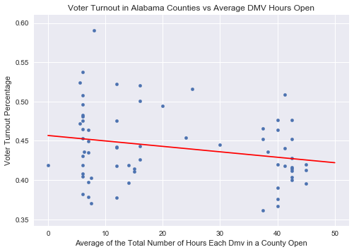

```python
plt.style.use('seaborn');
county.plot(x='total_hours',y='turnout',kind='scatter');
plt.title('Voter Turnout in Alabama Counties vs Average DMV Hours Open');
plt.xlabel('Average of the Total Number of Hours Each Dmv in a County Open');
plt.ylabel('Voter Turnout Percentage');
x_vec = np.linspace(0,50,200);
plt.plot(x_vec, x_vec*results.params[0] + results.params[1], 'r');
```

# PART 4: ADDITIONAL COVARIATES

Adding in education, poverty and unemployment data, all from US Census site.

```python
educ = pd.read_csv('Education_counties.csv')
educ = educ[['State','Area name','Percent of adults with a bachelor\'s degree or higher, 2013-17']].rename(columns={'Percent of adults with a bachelor\'s degree or higher, 2013-17':'percent_finished_college'})
educ = educ[educ['Area name'].str.contains('County')]
educ.rename(columns = {'Area name':'Area_name'},inplace=True)

pov = pd.read_csv('poverty_counties.csv')
pov = pov[['State','Area_Name','POVALL_2017']].rename(columns={'POVALL_2017':'pov_pop'})
pov = pov[pov['Area_Name'].str.contains('County')]
pov['pov_pop'] = pov['pov_pop'].str.replace(',','').astype(float)
pov.rename(columns = {'Area_Name':'Area_name'},inplace=True)

unemp = pd.read_csv('Unemployment_Counties.csv')
unemp = unemp[['State','Area_name','Median_Household_Income_2017','Unemployment_rate_2016']]
unemp = unemp[unemp['Area_name'].str.contains('County')]
unemp['Area_name'] = unemp['Area_name'].str.replace(r'(,.*)','')
unemp['Median_Household_Income_2017'] = unemp['Median_Household_Income_2017'].str.replace('$','').str.replace(',','').astype(float)
unemp
```

|  | State | Area_name | Median_Household_Income_2017 | Unemployment_rate_2016 |
| --- | --- | --- | --- | --- |
| 2 | AL | Autauga County | 58343.0 | 5.1 |
| 3 | AL | Baldwin County | 56607.0 | 5.3 |
| 4 | AL | Barbour County | 32490.0 | 8.3 |
| 5 | AL | Bibb County | 45795.0 | 6.4 |
| 6 | AL | Blount County | 48253.0 | 5.4 |
| ... | ... | ... | ... | ... |
| 3191 | WY | Sweetwater County | 75590.0 | 6.1 |
| 3192 | WY | Teton County | 90145.0 | 3.5 |
| 3193 | WY | Uinta County | 67404.0 | 5.8 |
| 3194 | WY | Washakie County | 57989.0 | 4.8 |
| 3195 | WY | Weston County | 56214.0 | 5.0 |

3006 rows × 4 columns

## Merging new covariates

```python
cov = educ.merge(pov, how='inner', on=['Area_name','State'])
cov = cov.merge(unemp, how='inner', on=['Area_name','State'])

# Getting county name "Area_Name"
cov['county'] = cov['Area_name'].str.extract(r'(.*\sCounty)')

# Keeping only Alabama
cov = cov[cov['State'] == 'AL']

# Dropping unnecessary columns
cov.drop(columns=['Area_name','State'],inplace=True)

cov.head()
```

|  | percent_finished_college | pov_pop | Median_Household_Income_2017 | Unemployment_rate_2016 | county |
| --- | --- | --- | --- | --- | --- |
| 0 | 25.0 | 7390.0 | 58343.0 | 5.1 | Autauga County |
| 1 | 30.7 | 21199.0 | 56607.0 | 5.3 | Baldwin County |
| 2 | 12.0 | 7414.0 | 32490.0 | 8.3 | Barbour County |
| 3 | 13.2 | 4137.0 | 45795.0 | 6.4 | Bibb County |
| 4 | 13.1 | 7343.0 | 48253.0 | 5.4 | Blount County |

## Adding in percent black or African American

Data comes from Citizen Voting Age Population from the American Community Survey. Looks at ages over 18 by race at the county level.

```python
cvap = pd.read_csv('voting_age_by_race\\County_utf-8.txt',encoding = 'utf-8')

# Renaming columns
dic = {'GEONAME': 'county', 'LNTITLE': 'race', 'ADU_EST': 'age18'}
cvap = cvap.rename(columns=dic)[['county','race','age18']]

# Filtering for only Alabama
cvap = cvap[cvap['county'].str.contains('Alabama')]
cvap['county'] = cvap['county'].str.extract(r'([\w\s]*), Alabama')

cvap
```

|  | county | race | age18 |
| --- | --- | --- | --- |
| 0 | Autauga County | Total | 41525 |
| 1 | Autauga County | Not Hispanic or Latino | 40575 |
| 2 | Autauga County | American Indian or Alaska Native Alone | 85 |
| 3 | Autauga County | Asian Alone | 415 |
| 4 | Autauga County | Black or African American Alone | 7620 |
| ... | ... | ... | ... |
| 866 | Winston County | Asian and White | 0 |
| 867 | Winston County | Black or African American and White | 4 |
| 868 | Winston County | American Indian or Alaska Native and Black or ... | 0 |
| 869 | Winston County | Remainder of Two or More Race Responses | 0 |
| 870 | Winston County | Hispanic or Latino | 415 |

871 rows × 3 columns

```python
total = cvap[cvap['race']=='Total']['age18'].reset_index()['age18']

# Adding the values of 'black alone' with 'black and white'
# Note: This fails to include black with other races
total_black = \
    cvap[cvap['race']=='Black or African American Alone'].reset_index()['age18'] + \
    cvap[cvap['race']=='Black or African American and White'].reset_index()['age18']

percent_black = total_black / total

cov['percent_black'] = percent_black
cov
```

|  | percent_finished_college | pov_pop | Median_Household_Income_2017 | Unemployment_rate_2016 | county | percent_black |
| --- | --- | --- | --- | --- | --- | --- |
| 0 | 25.0 | 7390.0 | 58343.0 | 5.1 | Autauga County | 0.184949 |
| 1 | 30.7 | 21199.0 | 56607.0 | 5.3 | Baldwin County | 0.089006 |
| 2 | 12.0 | 7414.0 | 32490.0 | 8.3 | Barbour County | 0.465071 |
| 3 | 13.2 | 4137.0 | 45795.0 | 6.4 | Bibb County | 0.228291 |
| 4 | 13.1 | 7343.0 | 48253.0 | 5.4 | Blount County | 0.015533 |
| ... | ... | ... | ... | ... | ... | ... |
| 62 | 30.2 | 31238.0 | 51644.0 | 5.6 | Tuscaloosa County | 0.295393 |
| 63 | 11.1 | 10975.0 | 41925.0 | 7.4 | Walker County | 0.057763 |
| 64 | 10.7 | 3303.0 | 44249.0 | 8.6 | Washington County | 0.242863 |
| 65 | 12.0 | 3392.0 | 25700.0 | 14.4 | Wilcox County | 0.693431 |
| 66 | 12.9 | 4980.0 | 38562.0 | 7.1 | Winston County | 0.006809 |

67 rows × 6 columns

## Merging with turnout and total hours data (county)

I'm going to keep county as it is and call this newly merged dataset county2

```python
county2 = county.join(cov.set_index('county'))
county2
```

| county | turnout | total_hours | const | percent_finished_college | pov_pop | Median_Household_Income_2017 | Unemployment_rate_2016 | percent_black |
| --- | --- | --- | --- | --- | --- | --- | --- | --- |
| Autauga County | 0.451907 | 37.500000 | 1 | 25.0 | 7390.0 | 58343.0 | 5.1 | 0.184949 |
| Baldwin County | 0.516226 | 25.166667 | 1 | 30.7 | 21199.0 | 56607.0 | 5.3 | 0.089006 |
| Barbour County | 0.378410 | 7.000000 | 1 | 12.0 | 7414.0 | 32490.0 | 8.3 | 0.465071 |
| Bibb County | 0.381759 | 6.000000 | 1 | 13.2 | 4137.0 | 45795.0 | 6.4 | 0.228291 |
| Blount County | 0.442832 | 16.000000 | 1 | 13.1 | 7343.0 | 48253.0 | 5.4 | 0.015533 |
| ... | ... | ... | ... | ... | ... | ... | ... | ... |
| Tuscaloosa County | 0.419756 | 45.000000 | 1 | 30.2 | 31238.0 | 51644.0 | 5.6 | 0.295393 |
| Walker County | 0.436313 | 38.333333 | 1 | 11.1 | 10975.0 | 41925.0 | 7.4 | 0.057763 |
| Washington County | 0.483021 | 6.000000 | 1 | 10.7 | 3303.0 | 44249.0 | 8.6 | 0.242863 |
| Wilcox County | 0.522279 | 12.000000 | 1 | 12.0 | 3392.0 | 25700.0 | 14.4 | 0.693431 |
| Winston County | 0.418845 | 6.000000 | 1 | 12.9 | 4980.0 | 38562.0 | 7.1 | 0.006809 |

67 rows × 8 columns

# PART 5: LINEAR REGRESSION 2

```python
reg2 = sm.OLS(endog=county2['turnout'], exog=county2.drop(columns=['turnout','pov_pop','Median_Household_Income_2017']))
results2 = reg2.fit(cov_type='HC3') # cov_type='HC3': Heteroscedasticity robust standard errors
print(results2.summary())
```

```
                            OLS Regression Results
==============================================================================
Dep. Variable:                turnout   R-squared:                       0.286
Model:                            OLS   Adj. R-squared:                  0.240
Method:                 Least Squares   F-statistic:                     4.829
Date:                Fri, 31 Jan 2020   Prob (F-statistic):            0.00187
Time:                        09:11:36   Log-Likelihood:                 121.82
No. Observations:                  67   AIC:                            -233.6
Df Residuals:                      62   BIC:                            -222.6
Df Model:                           4
Covariance Type:                  HC3
============================================================================================
                               coef    std err          z      P>|z|      [0.025      0.975]
--------------------------------------------------------------------------------------------
total_hours                 -0.0007      0.000     -1.933      0.053      -0.001    9.92e-06
const                        0.3236      0.033      9.785      0.000       0.259       0.388
percent_finished_college     0.0023      0.001      2.058      0.040       0.000       0.004
Unemployment_rate_2016       0.0143      0.004      3.450      0.001       0.006       0.022
percent_black               -0.0052      0.034     -0.150      0.880      -0.072       0.062
==============================================================================
Omnibus:                        1.953   Durbin-Watson:                   2.121
Prob(Omnibus):                  0.377   Jarque-Bera (JB):                1.508
Skew:                           0.178   Prob(JB):                        0.470
Kurtosis:                       2.357   Cond. No.                         256.
==============================================================================

Warnings:
[1] Standard Errors are heteroscedasticity robust (HC3)
```

# PART 5: INITIAL RESULTS

The following are screenshots of the nicer latex tables I produced using

```
print(results.summary().as_latex())
```

## Model 1

[figure not shown]

## Model 2

[figure not shown]

# PART 6: DISTANCE TO DMV

I now want to investigate if the distance to DMV's influences voter turnout. Since the ultimate goal is to find evidence of voter suppression I'm going to define the distance to DMV from low income housing as sourced from the following website:  
https://www.lowincomehousing.us/AL.html

```python
# The following cell is simply all the cities copy pasted from the link above, saved into cities_raw↔
```

```python
# cities_raw contains numbers before the cities so first just the cities are extracted
# and then are converted to a pandas dataframe

cities_list = re.findall(r'\d* (.*)',cities_raw)
cities_list[:5]
```

```
['Abbeville', 'Akron', 'Albertville', 'Alex City', 'Alexander City']
```

Using PyAutoGUI to get the housing addresses.

```python
import subprocess
import pyautogui
import time
import pyperclip

# Move cursor to corner if something goes wrong!
pyautogui.FAILSAFE = True

# Opening firefox
firefox_path = "C:\\Program Files\\Mozilla Firefox\\firefox.exe"
subprocess.Popen(firefox_path)
time.sleep(1)
pyautogui.hotkey('ctrl', 'l')
time.sleep(0.5)

# Going to low income housing website
pyautogui.typewrite('https://www.lowincomehousing.us/AL.html')
pyautogui.press('enter')
time.sleep(3.5)


address_list = []
for city in cities_list:

    while True:
        # Clicks on the searchbar, types the city then presses enter
        pyautogui.click(1250, 1949) # Position can be determined from pyautogui.position()
        pyautogui.hotkey('ctrl', 'a');pyautogui.press('delete');
        pyautogui.typewrite(city)
        time.sleep(1.9)

        pyautogui.click(1250, 2003)
        time.sleep(1.7)

        # Copying all of the text on the page
        pyautogui.hotkey('ctrl', 'a')
        pyautogui.hotkey('ctrl', 'c')
        raw_page_text = pyperclip.paste()

        # Extracting the first address given in the city
        regex = r'\r\n\r\n(\d+[\w\s,-]*?\d{5})\r'
        housing_addresses = re.findall(regex ,raw_page_text)

        if len(housing_addresses) > 0:
            address_list.append([housing_addresses[0], city])
            break
        else:
            pyautogui.hotkey('ctrl', 'l')
            pyautogui.typewrite('https://www.lowincomehousing.us/AL.html')
            pyautogui.press('enter');time.sleep(3.5)

    pyautogui.hotkey('alt', 'left')
    time.sleep(1.5)

address_list[:5]
```

```
[['194 Ash Street Abbeville, AL - 36310', 'Abbeville'],
 ['117 Gewin St Akron, AL - 35441', 'Akron'],
 ['2020 Al Highway 20 Albertville, AL - 35950', 'Albertville'],
 ['1702 Cornerstone D Alex City, AL - 35010', 'Alex City'],
 ['2110 County Road Alexander City, AL - 35010', 'Alexander City']]
```

## Cleaning the address list

```python
for i in range(len(address_list)-1, -1, -1):

    # This cleans the few that accidentally extracted the '1 of _' in front of the address
    if re.search('1 of ', address_list[i][0]) is not None:
        address_list[i][0] = re.findall(r'\r\n\r\n(.*)', address_list[i][0])[0]

    # This cleans the accidental repeats
    if re.search(address_list[i][1], address_list[i][0]) is None:
        del address_list[i]

address_list[:5]
```

```
[['194 Ash Street Abbeville, AL - 36310', 'Abbeville'],
 ['117 Gewin St Akron, AL - 35441', 'Akron'],
 ['2020 Al Highway 20 Albertville, AL - 35950', 'Albertville'],
 ['1702 Cornerstone D Alex City, AL - 35010', 'Alex City'],
 ['2110 County Road Alexander City, AL - 35010', 'Alexander City']]
```

## Converting to Pandas dataframe

```python
df = pd.DataFrame(address_list).rename(columns={0:'address', 1:'city'})
df.head()
```

|  | address | city |
| --- | --- | --- |
| 0 | 194 Ash Street Abbeville, AL - 36310 | Abbeville |
| 1 | 117 Gewin St Akron, AL - 35441 | Akron |
| 2 | 2020 Al Highway 20 Albertville, AL - 35950 | Albertville |
| 3 | 1702 Cornerstone D Alex City, AL - 35010 | Alex City |
| 4 | 2110 County Road Alexander City, AL - 35010 | Alexander City |

## Using GeoPy to convert addresses to lat, lon coordinates

Unfortunately the Nominatim only finds coordinates for about half the addresses.

```python
geolocator = Nominatim()

def get_coords(row):

    location = row['address']

    try:
        coords = geolocator.geocode(location)
        return(coords.latitude, coords.longitude)
    except (GeopyError, AttributeError):
        return np.nan
```

```python
coords = df.apply(lambda row: get_coords(row),axis=1)
df['coords'] = coords
sum(coords.isna())
```

```
101
```

## Trying MapQuest geolocator

Sadly this does no better!

```python
from geopy import OpenMapQuest
coordsgeolocator = OpenMapQuest('uGSeMMZm8wSxGqAqTzb3QOlEHBEFCe0O')

def get_coords(row):

    location = row['address']

    try:
        coords = geolocator.geocode(location)
        return(coords.latitude, coords.longitude)
    except (GeopyError, AttributeError):
        return np.nan
```

```python
coords2 = df.apply(lambda row: get_coords(row),axis=1)
sum(coords2.fillna(coords).isna())
```

```
101
```

## Scraping the remaining coordinates from the web

This site: https://stevemorse.org/jcal/latlon.php uses tons of different geolocators. So here I run PyAutoGUI to get the missing values from the site. It requires, however, the individual components of the address (street, city, state, zip) so first these are extracted from the addresses in the dataframe.

```python
def get_street(row):
    regex = '(.*?)\s*' + row['city']
    return re.findall(regex, row['address'])[0]

df['street'] = df.apply(lambda row: get_street(row), axis = 1)
df['zip'] = df['address'].str.extract('- (\d{5})')

df.head()
```

|  | address | city | street | zip | coords |
| --- | --- | --- | --- | --- | --- |
| 0 | 194 Ash Street Abbeville, AL - 36310 | Abbeville | 194 Ash Street | 36310 | NaN |
| 1 | 117 Gewin St Akron, AL - 35441 | Akron | 117 Gewin St | 35441 | NaN |
| 2 | 2020 Al Highway 20 Albertville, AL - 35950 | Albertville | 2020 Al Highway 20 | 35950 | NaN |
| 3 | 1702 Cornerstone D Alex City, AL - 35010 | Alex City | 1702 Cornerstone D | 35010 | NaN |
| 4 | 2110 County Road Alexander City, AL - 35010 | Alexander City | 2110 County Road | 35010 | (32.93697008119596, -85.98229254087278) |

```python
# Move cursor to corner if something goes wrong!
pyautogui.FAILSAFE = True

# Opening firefox
firefox_path = "C:\\Program Files\\Mozilla Firefox\\firefox.exe"
subprocess.Popen(firefox_path)
time.sleep(1)
pyautogui.hotkey('ctrl', 'l')
time.sleep(0.5)

# Going to lat lon website
pyautogui.typewrite('https://stevemorse.org/jcal/latlon.php')
pyautogui.press('enter')
time.sleep(2)

for i in range(len(df)):

    # Skipping values that already filled in
    if df['coords'][i] is not np.nan:
        continue

    # Inputting the full addresses
    pyautogui.press('tab', presses = 10)
    pyautogui.typewrite(df['street'][i])
    pyautogui.press('tab')
    pyautogui.typewrite(df['city'][i])
    pyautogui.press('tab')
    pyautogui.typewrite('AL')
    pyautogui.press('tab')
    pyautogui.typewrite(df['zip'][i])
    pyautogui.press('tab', presses = 2)
    pyautogui.press('enter')
    time.sleep(3)

    while(True):
        # Copying all of the text on the page
        time.sleep(.3)
        pyautogui.hotkey('ctrl', 'a')
        pyautogui.hotkey('ctrl', 'c')
        raw_page_text = pyperclip.paste()

        # Extract actual coordinate
        time.sleep(.3)
        regex = 'decimal\\t([\d\.]*)\\t([\d\.-]*)'
        coords_str = re.findall(regex ,raw_page_text)

        # This ensures we did extract coordinates
        if len(coords_str) > 0:
            df.at[i,'coords'] = float(coords_str[0][0]), float(coords_str[0][1])
            break

    pyautogui.hotkey('ctrl', 'r')
    time.sleep(2)

df
```

[output not shown]

## Caving in and using Google Maps API

Google Maps' geocoder is free for a small number of requests but still requires putting in billing info which annoys me but I've caved.  
Here's a short tutorial I followed to obtain a key: https://developers.google.com/maps/gmp-get-started

Thankfully after running the following cells I no longer have any null values!

```python
#TODO: Add your key here below
key = my_key

def get_maps_url(street,city,state,zipcode):

    # Changing spaces to plus signs
    street = re.sub('\s','+', street)
    city = re.sub('\s','+', city)

    url = 'https://maps.googleapis.com/maps/api/geocode/json?address='
    url += street+',+'+city+',+'+state+',+'+zipcode
    url += '&key=' + key

    return url
```

```python
for i in range(len(df)):

    # Skipping values that are already filled in
    if df['coords'][i] is not np.nan:
        continue

    # Getting URL and calling Google Maps API
    url = get_maps_url(df['street'][i],df['city'][i],'AL',df['zip'][i])
    response = requests.get(url)

    # Extracting longitude and latitude
    lng = response.json()['results'][0]['geometry']['location']['lng']
    lat = response.json()['results'][0]['geometry']['location']['lat']

    # Filling the coordinates into the dataframe
    df.at[i,'coords'] = (float(lat), float(lng))

sum(df['coords'].isna())
```

```
0
```

## Saving a checkpoint

```python
df.to_csv('low_income_AL.csv')
```

## Getting coordinates of DMVs using Google Maps and GeoPy

```python
from geopy import GoogleV3
coordsgeolocator = GoogleV3(key)

geo = dmv['full_address'].apply(coordsgeolocator.geocode)
dmv['coords'] = geo.apply(lambda x: (x.latitude, x.longitude))
dmv['coords'].head()
```

```
0           (31.5718352, -85.2504893)
1    (31.3085039, -86.48329129999999)
2    (33.2737256, -85.83607409999999)
3           (33.8370433, -86.2544223)
4            (34.761354, -87.0824045)
Name: coords, dtype: object
```

## Getting county of low income housing units using Google Maps and GeoPy

For some strange reason the Geocoder was timing out when I use an apply function, so I went the less ideal route of using a loop, however the dataframe is small enough that it was not really an issue.

```python
# Initializing column with NaN's
df['county'] = 'NA'

for i in range(len(df)):
    # Geocode
    geo = coordsgeolocator.geocode(df['address'][i])

    # Getting raw json
    raw = geo.raw['address_components']

    # Getting list of the individual parts
    parts = [components['long_name'] for components in raw]

    # Filtering for only the County (which occurs at random indices)
    regex = re.compile('.*County')
    county = list(filter(regex.match, parts))

    # Return the first element if success else NaN
    if len(county) > 0:
        df.at[i,'county'] = county[0]

df.head()
```

|  | address | city | street | zip | coords | county |
| --- | --- | --- | --- | --- | --- | --- |
| 0 | 194 Ash Street Abbeville, AL - 36310 | Abbeville | 194 Ash Street | 36310 | (31.561177, -85.250433) | Henry County |
| 1 | 117 Gewin St Akron, AL - 35441 | Akron | 117 Gewin St | 35441 | (32.871587, -87.73074) | Hale County |
| 2 | 2020 Al Highway 20 Albertville, AL - 35950 | Albertville | 2020 Al Highway 20 | 35950 | (34.257933, -86.213481) | Marshall County |
| 3 | 1702 Cornerstone D Alex City, AL - 35010 | Alex City | 1702 Cornerstone D | 35010 | (32.93783, -85.97339) | County Road |
| 4 | 2110 County Road Alexander City, AL - 35010 | Alexander City | 2110 County Road | 35010 | (32.93697008119596, -85.98229254087278) | County Road |

## Getting distance to nearest DMV for each address

```python
from geopy.distance import geodesic

def get_distance(row):

    # List of distance to each DMV
    distances = [geodesic(row['coords'], dmv).miles for dmv in list(dmv['coords'])]

    # Return only the minimum
    return min(distances)

distance = df.apply(lambda row: get_distance(row), axis = 1)
df['distance'] = distance
df.head()
```

|  | address | city | street | zip | coords | county | distance |
| --- | --- | --- | --- | --- | --- | --- | --- |
| 0 | 194 Ash Street Abbeville, AL - 36310 | Abbeville | 194 Ash Street | 36310 | (31.561177, -85.250433) | Henry County | 0.734327 |
| 1 | 117 Gewin St Akron, AL - 35441 | Akron | 117 Gewin St | 35441 | (32.871587, -87.73074) | Hale County | 9.363863 |
| 2 | 2020 Al Highway 20 Albertville, AL - 35950 | Albertville | 2020 Al Highway 20 | 35950 | (34.257933, -86.213481) | Marshall County | 8.322770 |
| 3 | 1702 Cornerstone D Alex City, AL - 35010 | Alex City | 1702 Cornerstone D | 35010 | (32.93783, -85.97339) | County Road | 14.240577 |
| 4 | 2110 County Road Alexander City, AL - 35010 | Alexander City | 2110 County Road | 35010 | (32.93697008119596, -85.98229254087278) | County Road | 14.180506 |

## Filtering out the two bad data points

Two of them have clearly incorrect coordinates resulting in being almost 400 miles from any DMV's.

```python
df = df[df['distance'] < 27]
```

## Grouping by county and using average distance to DMV

```python
distances = df.groupby('county').mean()
distances.head()
```

| county | distance |
| --- | --- |
| Alexander County | 21.357338 |
| Autauga County | 0.301252 |
| Baldwin County | 6.724584 |
| Barbour County | 7.808726 |
| Bibb County | 4.868061 |

## Merging distances to DMV with county voter turnout

Saving newest dataframe in county3, which includes the other covariates as well.

```python
county3 = county2.join(distances)
county3.head()
```

| county | turnout | total_hours | const | percent_finished_college | pov_pop | Median_Household_Income_2017 | Unemployment_rate_2016 | percent_black | distance |
| --- | --- | --- | --- | --- | --- | --- | --- | --- | --- |
| Autauga County | 0.451907 | 37.500000 | 1 | 25.0 | 7390.0 | 58343.0 | 5.1 | 0.184949 | 0.301252 |
| Baldwin County | 0.516226 | 25.166667 | 1 | 30.7 | 21199.0 | 56607.0 | 5.3 | 0.089006 | 6.724584 |
| Barbour County | 0.378410 | 7.000000 | 1 | 12.0 | 7414.0 | 32490.0 | 8.3 | 0.465071 | 7.808726 |
| Bibb County | 0.381759 | 6.000000 | 1 | 13.2 | 4137.0 | 45795.0 | 6.4 | 0.228291 | 4.868061 |
| Blount County | 0.442832 | 16.000000 | 1 | 13.1 | 7343.0 | 48253.0 | 5.4 | 0.015533 | 6.102763 |

# PART 7: FINAL REGRESSION

```python
reg3 = sm.OLS(endog=county3['turnout'], exog=county3.drop(columns=['turnout','pov_pop','Median_Household_Income_2017']))
results3 = reg3.fit(cov_type='HC3') # cov_type='HC3': Heteroscedasticity robust standard errors
print(results3.summary())
```

```
                            OLS Regression Results
==============================================================================
Dep. Variable:                turnout   R-squared:                       0.307
Model:                            OLS   Adj. R-squared:                  0.250
Method:                 Least Squares   F-statistic:                     4.540
Date:                Mon, 03 Feb 2020   Prob (F-statistic):            0.00139
Time:                        13:24:54   Log-Likelihood:                 122.81
No. Observations:                  67   AIC:                            -233.6
Df Residuals:                      61   BIC:                            -220.4
Df Model:                           5
Covariance Type:                  HC3
============================================================================================
                               coef    std err          z      P>|z|      [0.025      0.975]
--------------------------------------------------------------------------------------------
total_hours                 -0.0006      0.000     -1.695      0.090      -0.001    9.56e-05
const                        0.3337      0.031     10.609      0.000       0.272       0.395
percent_finished_college     0.0022      0.001      1.970      0.049    1.17e-05       0.004
Unemployment_rate_2016       0.0150      0.004      3.692      0.000       0.007       0.023
percent_black               -0.0119      0.033     -0.359      0.719      -0.077       0.053
distance                    -0.0019      0.001     -1.392      0.164      -0.005       0.001
==============================================================================
Omnibus:                        1.977   Durbin-Watson:                   2.091
Prob(Omnibus):                  0.372   Jarque-Bera (JB):                1.567
Skew:                           0.201   Prob(JB):                        0.457
Kurtosis:                       2.368   Cond. No.                         262.
==============================================================================

Warnings:
[1] Standard Errors are heteroscedasticity robust (HC3)
```

# PART 8: FINAL RESULTS

The following are screenshots of the nicer latex tables I produced using

```
print(results.summary().as_latex())
```

## Model 1

[figure not shown]

## Model 2

[figure not shown]

## Model 3

[figure not shown]

# PART 9: DISCUSSION

We see that including extra covariates did not alter the coeffecient estimate of our first variable of interest, `total_hours`. Quite counterintuitively, our results indicate that for each extra hour DMV's are open in a county, voter turnout actually *decreases* by 0.07 percentage points. This is a rather small effect as the voter turnout data had a sample standard deviation of approximately 4.68 percentage points, further it is not significant at traditional levels. Nonetheless, perhaps counties with low voter turnout have been targeted with longer DMV hours.

The second variable of interest, `distance`, which measures the average distance to the closest DMV for a sample of low income housing units, indicates that for each mile further away the nearest DMV is (to low-income housing) voter turnout decreases by 0.19 percentage points. So if, say, a DMV closed down and the next nearest one open was 10 miles further, we'd expect voter turnout to drop by 1.9 percentage points, a bit less than half a standard deviation. However, this estimate is not significant at traditional levels as well.

As for the other covariates, counties with higher percentage of college graduates and higher unemployment rates are associated with higher voter turnout, where both estimates are significant at the 95% level. Lastly the percent black/African American a county is is associated with a slight decrease in voter turnout, however it has a p-value of 0.72 so is not at all significant.

Overall, in this context there has been no significant evidence of voter suppression found. There's a number of possible explanations as well as much room for improvement. For one, it is possible that counties with low voter turnout have since been targeted with longer DMV hours, which if true would explain the countintuitive sign on our estimate. Further, this analysis leaves out DMV's which have closed down, which perhaps could be specified as having 0 hours and included in the average DMV hours. The distance to DMV variable was chosen rather ad hoc and different measures of DMV distance like, say, distance from the county center may be favored. In fact, percent of a county riding public transport may be more informative and capture better the difficulty of obtaining an ID to vote, however I've been unable to find such data at the county level in Alabama.

## Contact Me

Berkeley, California

Email: lukefeilberg@gmail.com